# DA Final project:

## Group 23

# **"The Effects of Smoking"**

##### Link to the data- https://www.kaggle.com/datasets/gauravduttakiit/smoker-status-prediction?resource=download

The dataset is a result of synthetic generation.

### Name of students:

Shahar Sadgasi  
Gal Tsaig  
Yair Yehud

[figure not shown]

# **Context**

**קובץ הנתונים:Smoker Status Prediction". מאגר הנתונים עוסק בזיהוי סטטוס עישון של אנשים באמצעות מדדים ביולוגיים ורפואיים. הוא כולל נתונים סינתטיים שנוצרו לצורכי מחקר, ומתאר פרמטרים כמו גיל, גובה, משקל, לחץ דם, רמות כולסטרול, המוגלובין, קריאטינין ועוד. המאגר נועד לשמש לפיתוח מודלים של למידת מכונה שיכולים לחזות האם אדם מעשן או לא, בהתבסס על המאפיינים הרפואיים שלו.**

# **Introduction** **& Basic **EDA.****

1. Importing Libraries
2. Read Data
3. EDA Project
4. Review on DA
5. Conclusions

# **1.** **Importing Libraries**

```python
import pandas as pd
import numpy as np
import matplotlib.pyplot as plt
import seaborn as sns
from sklearn.tree import DecisionTreeClassifier, plot_tree
from sklearn.model_selection import train_test_split
```

# **2.** **Read Data**

```python
url ="https://raw.githubusercontent.com/shaharsadgasi/Smoking-Status/refs/heads/main/train_dataset.csv"
df_smoking = pd.read_csv(url)
```

```python
df_smoking.tail()
```

|  | age | height(cm) | weight(kg) | waist(cm) | eyesight(left) | eyesight(right) | hearing(left) | hearing(right) | systolic | relaxation | ... | HDL | LDL | hemoglobin | Urine protein | serum creatinine | AST | ALT | Gtp | dental caries | smoking |
| --- | --- | --- | --- | --- | --- | --- | --- | --- | --- | --- | --- | --- | --- | --- | --- | --- | --- | --- | --- | --- | --- |
| 38979 | 40 | 165 | 60 | 80.0 | 0.4 | 0.6 | 1 | 1 | 107 | 60 | ... | 61 | 72 | 12.3 | 1 | 0.5 | 18 | 18 | 21 | 1 | 0 |
| 38980 | 45 | 155 | 55 | 75.0 | 1.5 | 1.2 | 1 | 1 | 126 | 72 | ... | 76 | 131 | 12.5 | 2 | 0.6 | 23 | 11 | 12 | 0 | 0 |
| 38981 | 40 | 170 | 105 | 124.0 | 0.6 | 0.5 | 1 | 1 | 141 | 85 | ... | 48 | 138 | 17.1 | 1 | 0.8 | 24 | 23 | 35 | 1 | 1 |
| 38982 | 40 | 160 | 55 | 75.0 | 1.5 | 1.5 | 1 | 1 | 95 | 69 | ... | 79 | 116 | 12.0 | 1 | 0.6 | 24 | 20 | 17 | 0 | 1 |
| 38983 | 55 | 175 | 60 | 81.1 | 1.0 | 1.0 | 1 | 1 | 114 | 66 | ... | 64 | 137 | 13.9 | 1 | 1.0 | 18 | 12 | 16 | 0 | 1 |

5 rows × 23 columns

```python
df_smoking.columns
```

```
Index(['age', 'height(cm)', 'weight(kg)', 'waist(cm)', 'eyesight(left)',
       'eyesight(right)', 'hearing(left)', 'hearing(right)', 'systolic',
       'relaxation', 'fasting blood sugar', 'Cholesterol', 'triglyceride',
       'HDL', 'LDL', 'hemoglobin', 'Urine protein', 'serum creatinine', 'AST',
       'ALT', 'Gtp', 'dental caries', 'smoking'],
      dtype='object')
```

```python
df_smoking.shape
```

```
(38984, 23)
```

# **3.** **EDA Project**

```python
df_smoking.dtypes
```

```
age                      int64
height(cm)               int64
weight(kg)               int64
waist(cm)              float64
eyesight(left)         float64
eyesight(right)        float64
hearing(left)            int64
hearing(right)           int64
systolic                 int64
relaxation               int64
fasting blood sugar      int64
Cholesterol              int64
triglyceride             int64
HDL                      int64
LDL                      int64
hemoglobin             float64
Urine protein            int64
serum creatinine       float64
AST                      int64
ALT                      int64
Gtp                      int64
dental caries            int64
smoking                  int64
dtype: object
```

```python
df_smoking.isnull().sum().sort_values()
```

```
age                    0
Gtp                    0
ALT                    0
AST                    0
serum creatinine       0
Urine protein          0
hemoglobin             0
LDL                    0
HDL                    0
triglyceride           0
dental caries          0
Cholesterol            0
relaxation             0
systolic               0
hearing(right)         0
hearing(left)          0
eyesight(right)        0
eyesight(left)         0
waist(cm)              0
weight(kg)             0
height(cm)             0
fasting blood sugar    0
smoking                0
dtype: int64
```

```python
df_smoking
```

|  | age | height(cm) | weight(kg) | waist(cm) | eyesight(left) | eyesight(right) | hearing(left) | hearing(right) | systolic | relaxation | ... | HDL | LDL | hemoglobin | Urine protein | serum creatinine | AST | ALT | Gtp | dental caries | smoking |
| --- | --- | --- | --- | --- | --- | --- | --- | --- | --- | --- | --- | --- | --- | --- | --- | --- | --- | --- | --- | --- | --- |
| 0 | 35 | 170 | 85 | 97.0 | 0.9 | 0.9 | 1 | 1 | 118 | 78 | ... | 70 | 142 | 19.8 | 1 | 1.0 | 61 | 115 | 125 | 1 | 1 |
| 1 | 20 | 175 | 110 | 110.0 | 0.7 | 0.9 | 1 | 1 | 119 | 79 | ... | 71 | 114 | 15.9 | 1 | 1.1 | 19 | 25 | 30 | 1 | 0 |
| 2 | 45 | 155 | 65 | 86.0 | 0.9 | 0.9 | 1 | 1 | 110 | 80 | ... | 57 | 112 | 13.7 | 3 | 0.6 | 1090 | 1400 | 276 | 0 | 0 |
| 3 | 45 | 165 | 80 | 94.0 | 0.8 | 0.7 | 1 | 1 | 158 | 88 | ... | 46 | 91 | 16.9 | 1 | 0.9 | 32 | 36 | 36 | 0 | 0 |
| 4 | 20 | 165 | 60 | 81.0 | 1.5 | 0.1 | 1 | 1 | 109 | 64 | ... | 47 | 92 | 14.9 | 1 | 1.2 | 26 | 28 | 15 | 0 | 0 |
| ... | ... | ... | ... | ... | ... | ... | ... | ... | ... | ... | ... | ... | ... | ... | ... | ... | ... | ... | ... | ... | ... |
| 38979 | 40 | 165 | 60 | 80.0 | 0.4 | 0.6 | 1 | 1 | 107 | 60 | ... | 61 | 72 | 12.3 | 1 | 0.5 | 18 | 18 | 21 | 1 | 0 |
| 38980 | 45 | 155 | 55 | 75.0 | 1.5 | 1.2 | 1 | 1 | 126 | 72 | ... | 76 | 131 | 12.5 | 2 | 0.6 | 23 | 11 | 12 | 0 | 0 |
| 38981 | 40 | 170 | 105 | 124.0 | 0.6 | 0.5 | 1 | 1 | 141 | 85 | ... | 48 | 138 | 17.1 | 1 | 0.8 | 24 | 23 | 35 | 1 | 1 |
| 38982 | 40 | 160 | 55 | 75.0 | 1.5 | 1.5 | 1 | 1 | 95 | 69 | ... | 79 | 116 | 12.0 | 1 | 0.6 | 24 | 20 | 17 | 0 | 1 |
| 38983 | 55 | 175 | 60 | 81.1 | 1.0 | 1.0 | 1 | 1 | 114 | 66 | ... | 64 | 137 | 13.9 | 1 | 1.0 | 18 | 12 | 16 | 0 | 1 |

38984 rows × 23 columns

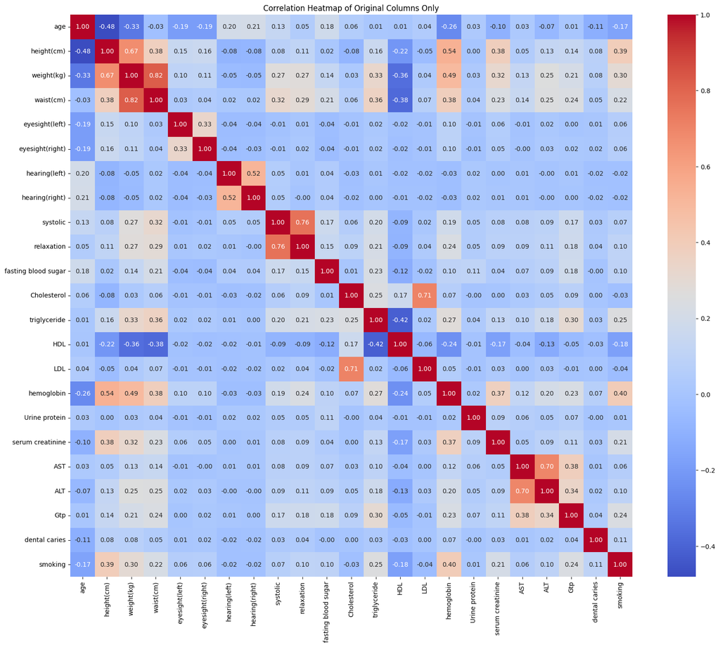

```python
original_columns = [
    'age', 'height(cm)', 'weight(kg)', 'waist(cm)', 'eyesight(left)', 'eyesight(right)',
    'hearing(left)', 'hearing(right)', 'systolic', 'relaxation', 'fasting blood sugar',
    'Cholesterol', 'triglyceride', 'HDL', 'LDL', 'hemoglobin', 'Urine protein',
    'serum creatinine', 'AST', 'ALT', 'Gtp', 'dental caries', 'smoking',
]

df_original = df_smoking[original_columns]


plt.figure(figsize=(20, 16))
correlation_matrix = df_original.corr(numeric_only=True)
sns.heatmap(correlation_matrix, annot=True, fmt=".2f", cmap="coolwarm", square=True)
plt.title('Correlation Heatmap of Original Columns Only')
plt.savefig("original_columns_correlation_heatmap.png", dpi=300)
plt.show()
plt.close()
```

# **4.** **Review on DA**

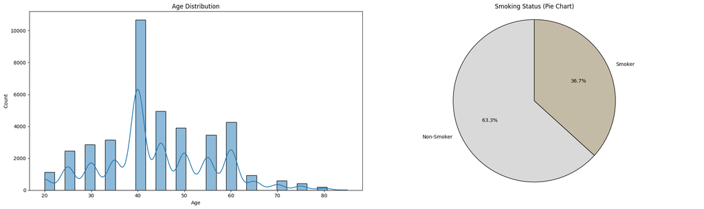

```python
fig, axes = plt.subplots(ncols=2, figsize=(20, 6))


sns.histplot(df_smoking['age'], bins=30, kde=True, ax=axes[0])
axes[0].set_title('Age Distribution')
axes[0].set_xlabel('Age')
axes[0].set_ylabel('Count')


smoking_counts = df_smoking['smoking'].value_counts()
labels = ['Non-Smoker', 'Smoker']
colors = ['#D9D9D9', '#C4BBA7']

axes[1].pie(smoking_counts, labels=labels, autopct='%1.1f%%', startangle=90, colors=colors, wedgeprops={'edgecolor': 'black'})
axes[1].set_title('Smoking Status (Pie Chart)')
axes[1].axis('equal')

plt.tight_layout()
plt.show()
```

#### טבלת סיכום סטטיסטית למדדים פיזיולוגיים

| מדד | ממוצע | חציון | סטיית תקן | מינימום | מקסימום |
| --- | --- | --- | --- | --- | --- |
| המוגלובין (Hemoglobin) | 14.62 | 14.8 | 1.57 | 4.9 | 21.1 |
| כולסטרול כללי | 196.88 | 195.0 | 36.35 | 55.0 | 445.0 |
| כולסטרול טוב (HDL) | 57.29 | 55.0 | 14.62 | 4.0 | 359.0 |
| לחץ דם דיאסטולי | 75.99 | 76.0 | 9.66 | 40.0 | 146.0 |
| לחץ דם סיסטולי | 121.48 | 120.0 | 13.64 | 71.0 | 233.0 |
| ראייה (ממוצע) | 1.01 | 1.0 | 0.41 | 0.1 | 9.9 |
| סוכר בצום | 99.34 | 96.0 | 20.64 | 46.0 | 423.0 |
| שמיעה (ממוצע) | 1.03 | 1.0 | 0.14 | 1.0 | 2.0 |
| שומנים בדם (Triglyceride) | 126.75 | 108.0 | 71.80 | 8.0 | 999.0 |

# **5.** **conclusions**

## **מסקנה 1**

## **השרשרת השקטה של לחץ הדם**

#### חלוקת טווח BMI לשלוש קבוצות:

| BMI Range | BMI Category |
| --- | --- |
| Less than 18.5 | Underweight |
| 18.5 – 24.9 | Normal weight |
| 25 and above | Obesity |

```python
df_smoking["BMI"] = df_smoking["weight(kg)"] / ((df_smoking["height(cm)"] / 100) ** 2)

correlation = df_smoking['BMI'].corr(df_smoking['systolic'])
print('The correlation between study load and sleep quality:', correlation)
```

[output not shown]

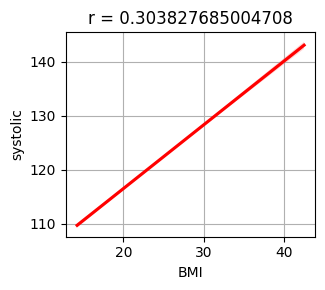

```python
plt.figure(figsize=(6, 3))
plt.subplot(1, 2, 2)
sns.regplot(x='BMI', y='systolic', data=df_smoking, scatter=False, line_kws={"color":"red"})
plt.title('r = 0.303827685004708')
plt.grid(True)

plt.tight_layout()
plt.show()
```

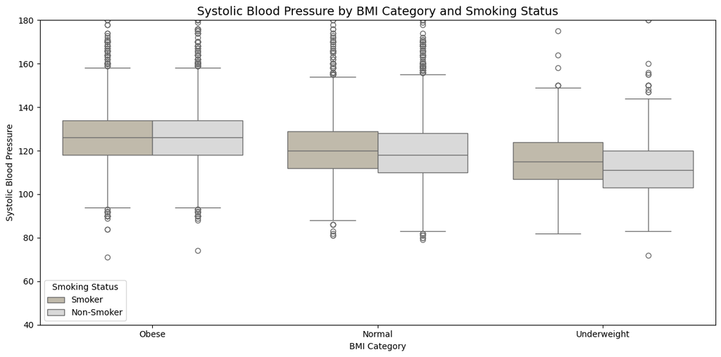

```python
conditions_BMI = [df_smoking['BMI'] < 18.5, (df_smoking['BMI'] >= 18.5) & (df_smoking['BMI'] < 25),(df_smoking['BMI'] >= 25)]

labels_BMI = ['Underweight', 'Normal', 'Obese']
df_smoking['BMI Category'] = np.select(conditions_BMI, labels_BMI)

df_smoking['smoking'] = df_smoking['smoking'].map({1: 'Smoker', 0: 'Non-Smoker'})

plt.figure(figsize=(12, 6))
sns.boxplot(data=df_smoking, x='BMI Category', y='systolic', hue='smoking',
    palette={'Non-Smoker': "#D9D9D9", 'Smoker': "#C4BBA7"})

plt.ylim(40, 180)
plt.title('Systolic Blood Pressure by BMI Category and Smoking Status', fontsize=14)
plt.xlabel('BMI Category')
plt.ylabel('Systolic Blood Pressure')
plt.legend(title='Smoking Status')
plt.tight_layout()
plt.show()
```

#### טווח רמת לחץ דם תקין ולא תקין:

| Systolic BP Range (mmHg) | Systolic Category |
| --- | --- |
| 120 or below | Normal |
| Above 120 | Abnormal (High) |

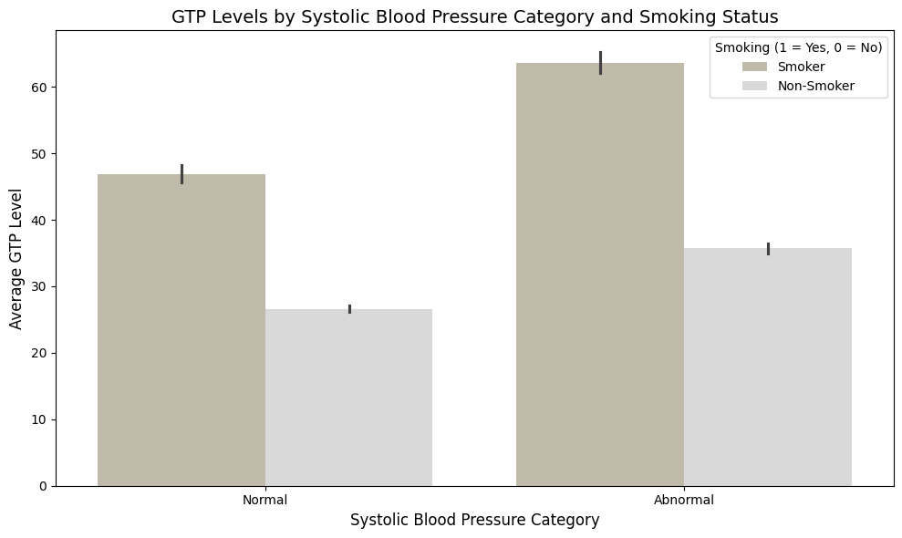

```python
systolic_threshold = 120
df_smoking['Systolic Category'] = 'Abnormal'
df_smoking.loc[df_smoking['systolic'] <= systolic_threshold, 'Systolic Category'] = 'Normal'

df_smoking['Smoking Status'] = df_smoking['smoking'].map({0: 'Non-Smoker', 1: 'Smoker'})

palette_updated = { 'Non-Smoker': "#D9D9D9",  'Smoker': "#C4BBA7"}

plt.figure(figsize=(10, 6))
sns.barplot( data=df_smoking, x='Systolic Category',  y='Gtp',   hue='smoking',   palette=palette_updated)
plt.title('GTP Levels by Systolic Blood Pressure Category and Smoking Status', fontsize=14)
plt.xlabel('Systolic Blood Pressure Category', fontsize=12)
plt.ylabel('Average GTP Level', fontsize=12)
plt.legend(title='Smoking (1 = Yes, 0 = No)')
plt.tight_layout()
plt.show()
```

##### תובנה 2:השפעת משולבת של עישון ולחץ דם גבוה על תפקודי כבד

השילוב של עישון ולחץ דם גבוה מהווה "כפל סיכון" לבריאות הכבד. מדובר באות אזהרה לכך שפגיעה בכבד אינה נגרמת רק בעקבות תזונה או אלכוהול, היא נגרמת גם לאור השילוב של עישוןן עם לחץ דם גובה.

#### חלוקת טווח גילאים לארבע קבוצות:

| Age Range | Age Category |
| --- | --- |
| 20–30 | Young |
| 31–50 | Middle |
| 51–65 | Old |
| 66–85 | Old Plus |

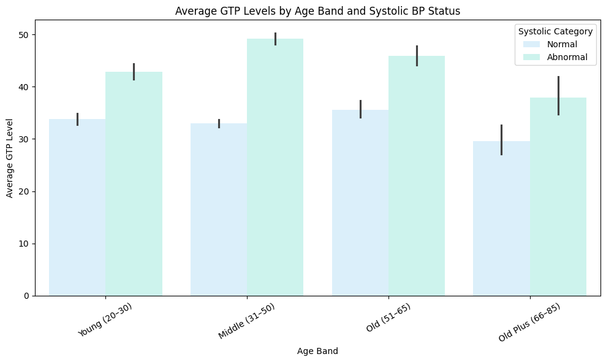

```python
pastel_palette = {'Normal': '#D6F0FF', 'Abnormal':'#C7F9F1'}


bins = [19, 30, 50, 65, 85]
age_order = ['Young (20–30)', 'Middle (31–50)', 'Old (51–65)', 'Old Plus (66–85)']
df_smoking['Age Category'] = pd.cut(df_smoking['age'], bins=bins, labels=age_order, right=True)
df_smoking['Age Category'] = pd.Categorical(df_smoking['Age Category'], categories=age_order, ordered=True)


plt.figure(figsize=(10, 6))
sns.barplot( data=df_smoking, x='Age Category',  y='Gtp',  hue='Systolic Category',  order=age_order,  palette=pastel_palette)

plt.title('Average GTP Levels by Age Band and Systolic BP Status')
plt.xlabel('Age Band')
plt.ylabel('Average GTP Level')
plt.xticks(rotation=30)
plt.tight_layout()
plt.show()
```

##### תובנה 3:השפעה מצטברת של גיל ולחץ דם גבוה על תפקודי כבד

בכל קבוצת גיל, אנשים בעלי לחץ דם סיסטולי גבוה מציגים ממוצע GTP גבוה יותר מאשר אלו עם לחץ דם תקין. הפער המשמעותי ביותר מופיע בקטגוריה: Middle שמאופיינת בטווח גילאים 31-50.

**סיכום מסקנה 1** **האופן שבו לחץ הדם משפיע על מערכות הגוף מושפע מה BMI (גורם פיזיולוגי) ומהרגלי עישון(גורם התנהגותי). אצל אנשים עם BMI גבוה, העלייה בלחץ הדם מוסברת לרוב על ידי עומס מטבולי. ולעומת זאת, אצל בעלי BMI נמוך, אין הצדקה מטבולית לעלייה בלחץ הדם – ולכן העישון מתבלט כגורם מרכזי. בנוסף, נמצא כי אנשים עם לחץ דם גבוה סובלים גם מ־רמות GTP גבוהות, מה שמעיד על פגיעה בתפקוד הכבד (לא רק בלב כצפוי). השפעה זו בולטת במיוחד בגילאי 31–50מה שמעיד על השפעה מצטברת של לחץ הדם על הכבד. לסיכום, לחץ דם גבוה הוא לא רק בעיה לבבית – אלא גם סמן לפגיעה בכבד, במיוחד אצל מעשנים ובעלי BMI גבוה, כשההשפעה ניכרת בעיקר בגילאי 31–50 – מה שמעיד על נזק מצטבר משילוב של עומס מטבולי והרגלים מזיקים.**

## **מסקנה 2**

## **עישון ושיבוש האיזון השומני בגוף**

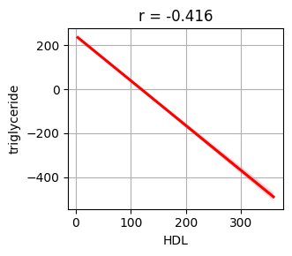

```python
plt.figure(figsize=(6, 3))
plt.subplot(1, 2, 2)
sns.regplot(x='HDL', y='triglyceride', data=df_smoking, scatter=False, line_kws={"color":"red"})
plt.title('r = -0.416')
plt.grid(True)
plt.tight_layout()
plt.show()
```

#### חלוקת טווח רמות הטריגליצרידים:

| Triglyceride Range (mg/dL) | Triglyceride Category |
| --- | --- |
| פחות מ־150 | Normal (נורמלי) |
| 150 – 199 | Borderline High (גבוה גבולי) |
| 200 ומעלה | High (גבוה מאוד) |

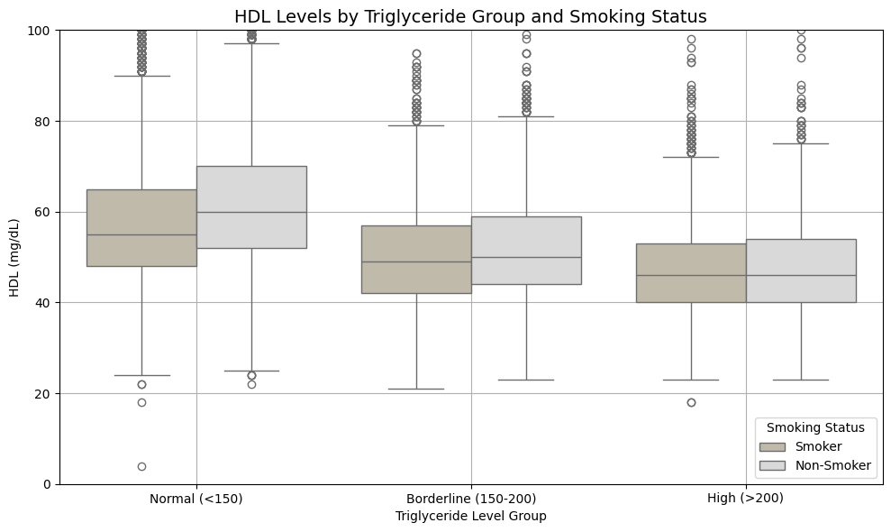

```python
df_smoking['Triglyceride Group'] = pd.cut(  df_smoking['triglyceride'], bins=[0, 150, 200, df_smoking['triglyceride'].max()],
labels=['Normal (<150)', 'Borderline (150-200)', 'High (>200)'], include_lowest=True)

plt.figure(figsize=(10, 6))
sns.boxplot( data=df_smoking,   x='Triglyceride Group',  y='HDL',  hue='smoking',   palette={"Non-Smoker": "#D9D9D9", "Smoker": "#C4BBA7"})

plt.ylim(0, 100)
plt.title("HDL Levels by Triglyceride Group and Smoking Status", fontsize=14)
plt.xlabel("Triglyceride Level Group")
plt.ylabel("HDL (mg/dL)")
plt.grid(True)
plt.legend(title="Smoking Status")
plt.tight_layout()
plt.show()
```

##### תובנה 1: האיזון המתערער בין הכולסטרול לשומנים

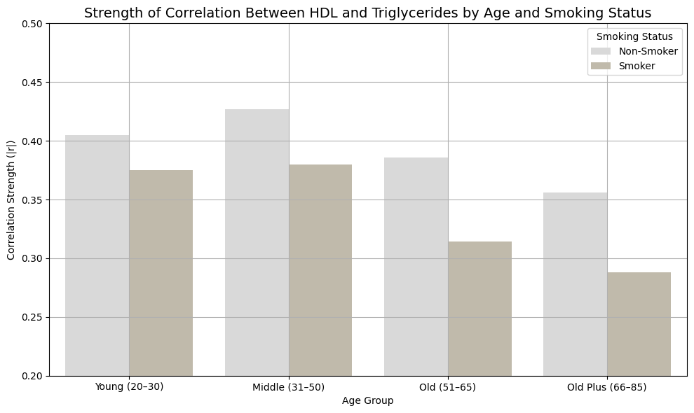

```python
r_by_group = pd.DataFrame({
    'Age Group': ['Young (20–30)', 'Young (20–30)', 'Middle (31–50)', 'Middle (31–50)',
                  'Old (51–65)', 'Old (51–65)', 'Old Plus (66–85)', 'Old Plus (66–85)'],
    'Smoking Status': ['Non-Smoker', 'Smoker'] * 4,
    'Correlation (r)': [-0.405, -0.375, -0.427, -0.380, -0.386, -0.314, -0.356, -0.288]
})

# הוספת עוצמת מתאם מוחלטת
r_by_group['Correlation Strength'] = r_by_group['Correlation (r)'].abs()

# צבעים מותאמים
custom_palette = {"Non-Smoker": "#D9D9D9", "Smoker": "#C4BBA7"}

# ציור הגרף
plt.figure(figsize=(10, 6))
sns.barplot(x='Age Group', y='Correlation Strength', hue='Smoking Status', data=r_by_group, palette=custom_palette)
plt.title("Strength of Correlation Between HDL and Triglycerides by Age and Smoking Status", fontsize=14)
plt.xlabel("Age Group")
plt.ylabel("Correlation Strength (|r|)")
plt.ylim(0.2, 0.5)
plt.grid(True)
plt.tight_layout()
plt.show()
```

##### תובנה 2: היחלשות ביולוגית כפולה: גיל + עישון = סיכון במנגנון האיזון השומני בגוף

הקשר בין HDL לשומנים נחלש יותר עם הגיל, במיוחד אצל מעשנים. ככל הנראה מדובר בהשפעה מצטברת של עישון מתמשך על מנגנוני ההגנה של הגוף, ובעיקר אלו הקשורים ללב ולכלי הדם. כלומר, לא בהכרח הגיל עצמו הוא שגורם לפגיעה, אלא ככל שהאדם מבוגר יותר וחשוף לעישון לאורך זמן – הגוף מאבד מיכולתו להגן על עצמו באופן יעיל.

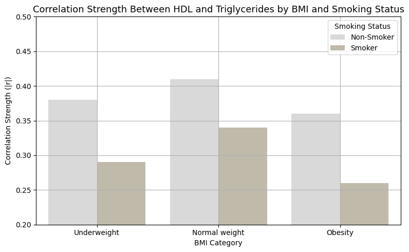

```python
r_bmi_group = pd.DataFrame({
    'BMI Category': ['Underweight', 'Underweight', 'Normal weight', 'Normal weight', 'Obesity', 'Obesity'],
    'Smoking Status': ['Non-Smoker', 'Smoker'] * 3,
    'Correlation (r)': [-0.38, -0.29, -0.41, -0.34, -0.36, -0.26]
})

r_bmi_group['Correlation Strength'] = r_bmi_group['Correlation (r)'].abs()


custom_palette = {"Non-Smoker": "#D9D9D9", "Smoker": "#C4BBA7"}

plt.figure(figsize=(8, 5))
sns.barplot(   x='BMI Category',   y='Correlation Strength',   hue='Smoking Status'  ,  data=r_bmi_group,   palette=custom_palette)

plt.title("Correlation Strength Between HDL and Triglycerides by BMI and Smoking Status", fontsize=13)
plt.xlabel("BMI Category")
plt.ylabel("Correlation Strength (|r|)")
plt.ylim(0.2, 0.5)
plt.grid(True)
plt.tight_layout()
plt.show()
```

##### תובנה 3:עישון מחליש את הקשר המגן של HDL מול טריגליצרידים

נמצא כי הקשר השלילי בין כולסטרול טוב (HDL) לבין רמות שומנים בדם (טריגליצרידים) קיים בכל קבוצות ה־BMI, אך הוא חזק יותר אצל לא־מעשנים. המשמעות היא שעישון מחליש את מנגנון האיזון הטבעי של הגוף – שבו HDL מגן מפני הצטברות שומנים – ובכך מגביר את הסיכון לפגיעה בכלי הדם.

**סיכום מסקנה 2** **עישון פוגע במנגנוני האיזון התקין בין סוגי השומנים השונים בדם של הגוף באופן שיטתי ומצטבר – במיוחד עם העלייה בגיל. הקשר המגן של HDL מול שומנים נחלש הן אצל מעשנים והן בקרב אנשים מבוגרים, אך הפגיעה חמורה יותר כאשר שני הגורמים מצטלבים. זו עדות לכך שעישון לאורך זמן משבש את היכולת של הגוף לווסת שומנים בדם – גם אם מדדי ה־HDL עצמם תקינים – וכך מגביר את הסיכון למחלות לב וכלי דם באופן "שקט".**

## **מסקנה 3**

## **העישון מול הכליות**

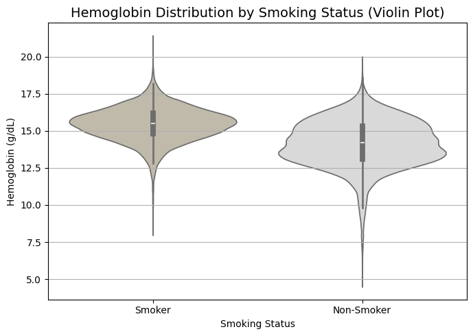

```python
df_smoking['smoking_status'] = df_smoking['smoking'].map({1: 'Smoker', 0: 'Non-Smoker'})

plt.figure(figsize=(7, 5))
sns.violinplot(data=df_smoking,  x='smoking',  y='hemoglobin',  hue='smoking',  palette={"Non-Smoker": "#D9D9D9", "Smoker": "#C4BBA7"}, inner='box',  legend=False  )
plt.title("Hemoglobin Distribution by Smoking Status (Violin Plot)", fontsize=14)
plt.xlabel("Smoking Status")
plt.ylabel("Hemoglobin (g/dL)")
plt.grid(True, axis='y')
plt.tight_layout()
plt.show()
```

##### תובנה 1: המוגלובין בקרב מעשנים

הגרף מראה שרמות ההמוגלובין גבוהות יותר בקרב מעשנים – עדות לכך שהגוף מגיב לעישון על ידי ייצור מוגבר של המוגלובין, כמנגנון פיצוי לחוסר בחמצן שנגרם מחשיפה לעשן סיגריות ייתכן שהעישון משפיע על רמות ההמוגלובין דרך ירידה בחמצון הדם, הגורמת לגוף לייצר יותר תאי דם אדומים

```python
correlation = df_smoking['serum creatinine'].corr(df_smoking['hemoglobin'])
print('The correlation between study load and sleep quality:', correlation)
```

[output not shown]

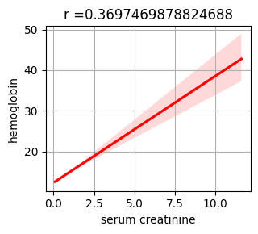

```python
plt.figure(figsize=(6, 3))
plt.subplot(1, 2, 2)
sns.regplot(x='serum creatinine', y='hemoglobin', data=df_smoking, scatter=False, line_kws={"color":"red"})
plt.title('r =0.3697469878824688')
plt.grid(True)
plt.tight_layout()
plt.show()
```

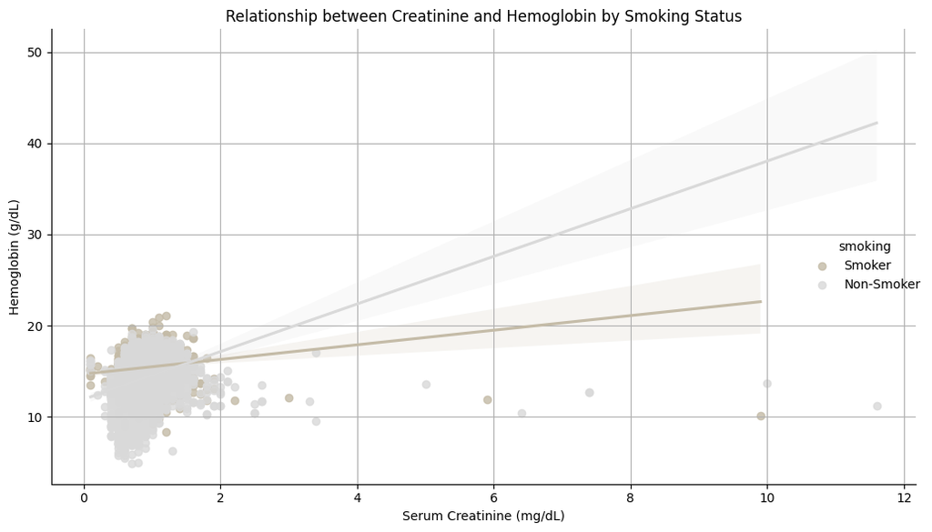

```python
sns.lmplot( data=df_smoking, x='serum creatinine',  y='hemoglobin', hue='smoking',  palette={"Non-Smoker": "#D9D9D9", "Smoker": "#C4BBA7"},  aspect=1.5,   height=6)
plt.title('Relationship between Creatinine and Hemoglobin by Smoking Status')
plt.xlabel('Serum Creatinine (mg/dL)')
plt.ylabel('Hemoglobin (g/dL)')
plt.grid(True)
plt.tight_layout()
plt.show()
```

##### תובנה 2: הקשר בין רמות קריאטינין להמוגלובין

רמות הקריאטינין והמוגלובין מראות מגמת עליה דומה בקרב אנשים מעשנים ולא מעשנים. ניתן לראות שבקרב מעשנים קיים קשר יותר חלש מה שיכול להעיד שהעישון "משבש" את הקשר הפיזיולוגי הטבעי בין קריאטינין (תפקוד הכליות) לבין יצור ההמוגלובין. לסיכום, למרות שקיים קשר חיובי בין רמות הקריאטינין והמוגלובין אצל כולם, הקשר חזק ומשמעותי יותר בקרב לא־מעשנים, מה שעשוי להעיד על השפעה של העישון על מנגנוני ויסות החמצן ותפקוד הכליות.

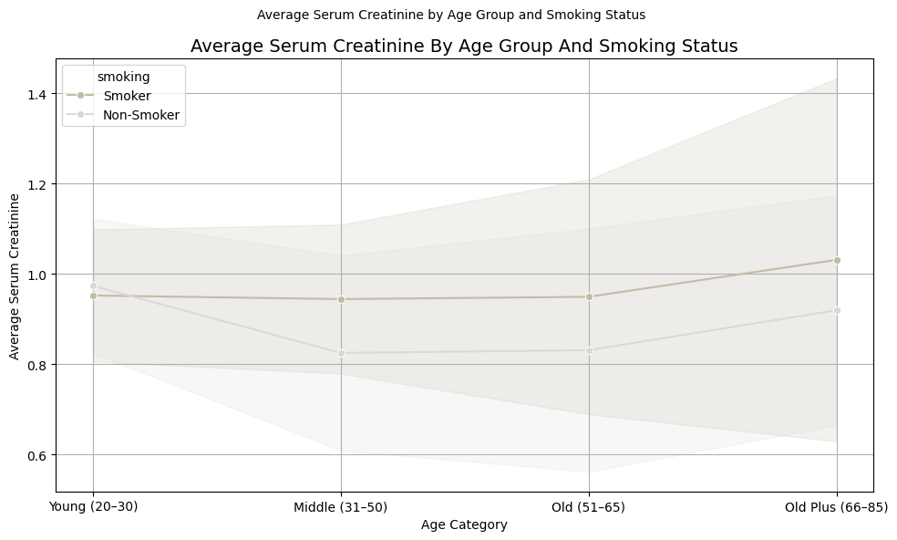

```python
plt.figure(figsize=(10, 6))
sns.lineplot( data=df_smoking, x='Age Category',y='serum creatinine', hue='smoking', marker='o', palette={"Non-Smoker": "#D9D9D9", "Smoker": "#C4BBA7"}, errorbar='sd')

plt.title('Average Serum Creatinine By Age Group And Smoking Status', fontsize=14)
plt.suptitle('Average Serum Creatinine by Age Group and Smoking Status', fontsize=10)
plt.ylabel('Average Serum Creatinine')
plt.xlabel('Age Category')
plt.grid(True)
plt.tight_layout()
plt.show()
```

##### תובנה : הקשר בין קריאטינין לעישון

בעוד שהעישון עצמו אינו משפיע על הקריאטינין באופן ישיר, הוא תורם לרמות גבוהות של המוגלובין, לעלייה בלחץ דם ולשינויים מטבוליים אחרים. כולם יחד עשויים ליצור עומס על הכליות בטווח הארוך, במיוחד באוכלוסייה בגילאי 31–65.

**סיכום מסקנה 3** **אף שעישון לא משפיע ישירות על תפקוד הכליות לפי מדד הקריאטינין, הוא משפיע בעקיפין דרך העלאת המוגלובין וגורמים נוספים. השפעה מצטברת זו יוצרת עומס כלייתי שעלול להוביל לפגיעה בתפקוד הכליות לאורך זמן – במיוחד בקרב מעשנים בגיל בינוני ומעלה.**